# dPrep - Course Summary & Exam Preparation

Hannes Datta

### Welcome to the final lecture in dPrep!

If you haven't done so, please **explore the exam page & example questions** at https://dprep.hannesdatta.com/docs/exam.

The **course evaluation** is live at https://app.evalytics.nl. Please voice your opinions!

### Agenda

- Course summary
- From here onwards
  - During your studies
  - After your studies
- Course evaluation
- Exam preparation
- Remaining questions / Q&A

### Course framework

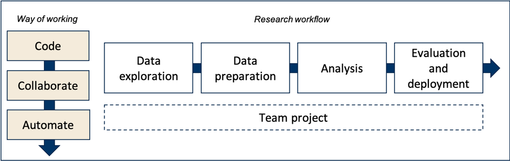

### Positioning in the study program

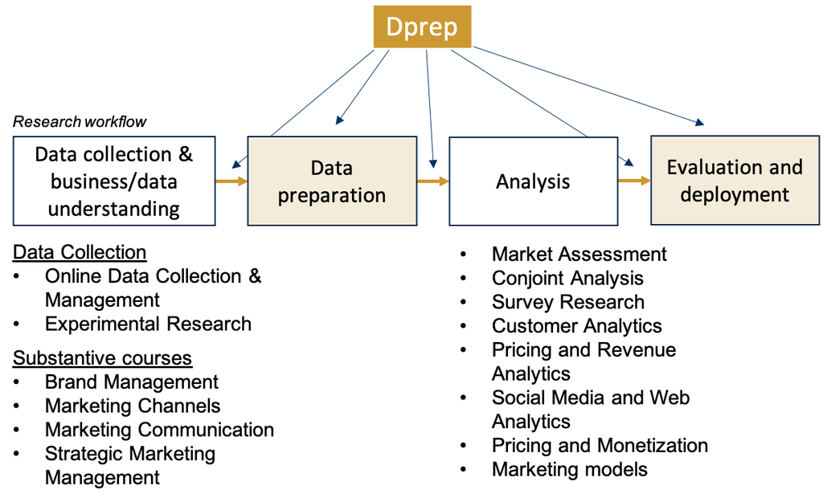

### Lessons learnt #1: Versioning and Project Management with Git(Hub) (I)

- Scrum & the project board as a way to collaborate with one another
  - Writing issues is hard (!)
  - Seems to put a lot of structure on stuff, did it work out?
  - Recall how to work together – team <-> individual
- Versioning can be powerful!
  - `git log` to see recent commits
  - delete stuff that isn't needed (“housekeeping”), roll back when you want (`git checkout COMMITID -b branch`)
  - Oh no, not authenticated! (browser authentication works best)
  - Oh no! Can't push! (pull first!)
  - Use GUIs (e.g., in R or VS Code), complemented with Git Bash

### Lessons learnt #1: Versioning and Project Management with Git(Hub) (II)

- Ready to use Git/versioning in a business setting
  - clone repositories, switch brandes (`git switch BRANCHNAME` or `git checkout BRANCHNAME`)
  - Know what to version, and what not
  - Use `.gitignore` (and know what it CANNOT do)
  - Work together using issues, feature branches & pull requests (PRs)/merge requests
- Collaborate on open source projects
  - You know what forks are!
  - You may even actually contributed to public projects!

### Lessons learnt #2: Data Exploration

- RMarkdown! (mixing code with reporting)
  - ability to quickly produce clean documents to share!
  - uh… but how to run it with make? (tip: `R -e 'rmarkdown::render(input = "test_render.Rmd", output_file = "test_render.html")'`)
  - **verify you can render markdown documents to HTML and PDF!**
- Doing data quality checks?
  - getting back to your data supplier if needed!
  - reporting summary statistics (`summary`, `table`, `dplyr` for summary stats by group)
  - plotting with `ggplot2`
- Use RMarkdown when it is *useful* (i.e., to produce a doc, slides; NOT for data cleaning)

### Lessons learnt #3: Data Engineering

- Why do we actually *have* to clean up data?!
  - re-watch my summary: https://youtu.be/z_Hh1jlL1Ac
- Data prep code can be complex
  - so… use cheatsheets (also for the exam!)
  - know & apply common data operations (what are those?)!
- Make setup-ITO blocks
  - setup to load libraries, **then** input, transformation, output!
  - super crucial for `make`, too! (know why?)
- Modularize code, loop, and use functions

### Lessons learnt #4: Pipeline building and automation

- Clarity about *where* to store stuff
  - review! (components - `src`, `gen`, `data`; modules - e.g., `analysis`, `data-prep`, …)
- Run the work others have done
  - my work, your work, somebody else's work
- Discover mistakes in code
  - e.g., packages that weren't loaded, order of cells/code
- Save time!
  - but, yeah, NOT at the beginning when you still learn
- Continuously improve documentation & code

### Common mistakes w/ make

- Wrong: One “all” rule with all targets as prerequisites (correct: final products/files to be built)
- Wrong: Incomplete dependencies (correct: all input files + own source code per recipe)
- Wrong: Multiple Rscript execution commands per recipe (correct: write separate rules)
- Gradually build your makefile. **Go in baby steps!**
- Happy to take a look at your repositories now - anyone?

### Any other questions about your projects?

**We can address them now!**

### Reflection about the course

- it's amazing to see you learn & grow!
  - responded very well to overhauled engineering tutorial :)
  - can talk to you as “members of my own development team”!
  - many started R from scratch; some could program but still were challenged with make and GitHub!
- we've seen a lot: different projects, data sets, tools, “way of doing things”, way of coding, videos, websites

My recommendation: **take time to let it sink in.** And trust in my choice of teaching you this. **Your hard work will pay off.**

### Looking ahead: During your studies (I)

- **Selectively** implement across classes or projects
  - e.g., some projects just benefit from better directory structure, while others may need “more”
  - risk of “losing” the skill (!)
- Realize it takes time to learn (and debug!)
  - it took me years to become proficient
  - onboard team members to “your” way of working

### Looking ahead: During your studies (II)

- Use for thesis!
  - but, be aware your skills are *so* fresh, your professor likely has never heard about it! –> use, teach, show how productive you are!
- Build your job market profile
  - have a compelling about page on GitHub
  - “pin” your best repositories (but don't call them `dprep-team-X`; remember)

### Looking ahead: During your studies (III)

- Become part of the open science community at Tilburg
  - contribute to [Tilburg Science Hub](https://tilburgsciencehub.com)
  - apply for a job at tilburg.ai
  - improve music-to-scrape.org
  - follow us on [LinkedIn](https://www.linkedin.com/company/tilburgsciencehub/) and [X](https://twitter.com/tilburgscience)
- Invest in your research skills (e.g., Docker, coding, the cloud)

### Looking ahead: After your studies

- automate stuff, save time for the things you love!
- write packages (e.g., recently seen internal AirBnB and Walmart packages)
- be confident - and keep on learning (e.g., [Tilburg Science Hub](https://tilburgsciencehub.com), [Datacamp](https://datacamp.com), [Data carpentry](https://datacarpentry.org), [software carpentry](https://softwarecarpentry.org), [The Turing Way](https://the-turing-way.netlify.app/welcome))

### Next steps: Submissions and preparing for the exam

- Deadline for project coming up next week!
  - remember: **test it** on different computers and operating systems
  - **do not use** absolute paths!
  - verify data can be downloaded smoothly
  - test `make` thoroughly
  - avoid testing any statistical assumptions - this is about a running workflow, not about research methods!

### Exam planning (I)

- Organization
  - 3 April (time tba; 3 hours)
  - On campus, using **TestVision**
- Software & materials
  - access to R/RStudio, Git, make
  - no access to the internet
  - I'm making selecting resources available on the instruction page - [check them out here](https://github.com/hannesdatta/course-dprep/raw/master/content/docs/exam/cheatsheets-exam.zip)
  - package installation: I will test the exam on Thu next week; if a package is not installed (yet), I will include installation instructions on the exam.
- familiarize yourselves with how TestVision works (link on Canvas + will show here) + review [example questions](https://dprep.hannesdatta.com/docs/exam/examplequestions/) (next slides…)

### Learning goals, distribution of points + tips (I)

- 100 points in total, about 9 questions
- Mix of open and closed questions
- LG 1: Use R to clean and transform data for analysis [synthesis; **20% of points**]
  - know core concepts and corresponding code in `tidyverse`/`dplyr`: e.g., aggregation, merging, de-duplication, reshaping, data conversions, regular expressions, dealing with time, pivoting)
  - become fast in coding - no time to “look up” these commands elaborately
  - open `.Rdata`, submit code and/or submit saved `.Rdata` file.
  - several “smaller” questions
  - I simulated the data

### Learning goals, distribution of points + tips (II)

- LG 2: Use GitHub for managing empirical research projects [evaluation; **10% of points**]
  - conceptual questions on GitHub issues, project boards, Scrum, etc.
- LG 3: Use Git/GitHub for versioning files and collaboration on privately-shared and publicly-available (open science) GitHub repositories [application; **30% of points**]
  - question type: download a zipped repository
  - Be prepared to work with Git Bash (e.g., `git checkout`, `git merge`, `git add`, `git status`, `git log`, `git branch`, etc.)
  - download git repository, unzip, do your commits, zip again and submit as a zipfile
  - know how to make commits with commit messages, create branches, switch branches, etc.

### Learning goals, distribution of points + tips (III)

- LG 4: Use R for generating automatic reports (e.g., to assess data quality, to report research findings in a paper) and deploying research findings in novel ways (e.g., apps) [comprehension; **15% of points**]
  - inspect “new”/unseen data
  - covering `ggplot2` for data visualization
  - When handing in documents, check what I require (for `.Rmd`, I sometimes ask for rendered `.pdf` documents - does it work on your computer?)
- LG 5: Make
  - Use Workflow Management Tools to create and run portable, automated, and reproducible research pipelines [application; **25% of points**]
  - Expect a `zip` file containing a make pipeline
  - Complete a few smaller tasks: run, correct and develop new `make` workflow

### Learning goals, distribution of points + tips (IV)

- Work on a joint cheat sheet (link has been shared on Canvas) - deadline one week before the exam
- Be prepared to download data sets from Testvision (`.Rdata`) - on the Cover page of the exam or in a specific question on the exam.

### Next steps: Official course evaluation

- Course evaluation has been immensely important to this course
  - this semester: overhauled all tutorials (e.g., ggplot in week 2, advanced engineering in week 4)
  - last semester: switched order of sessions, revised GitHub tutorial/onboarding, new data sets, coaching sessions with breakout groups on campus and online
- Course evaluation has been critical to my career
  - Without my past evaluations, I wouldn't be teaching to you today
  - I will look at all comments. Based on student feedback, we now have Q&A for setups & additional Q&As towards the end of the course.
  - **Scores are most important to show importance of this course**
- You will be invited via [Evalytics](https://app.evalytics.nl/#/login) at the end of the week

### Next steps: Self- and peer assessment

- You will be invited via e-mail
- To be filled in using Google Forms

### Informal feedback

- Coaching sessions? (Online, offline)
- How was it for beginners?
- What's are three things you'd like me to change?

### Stay in touch!

- Stay in touch
  - [LinkedIn](https://www.linkedin.com/in/hannes-datta/),[YouTube](https://www.youtube.com/c/hannesdatta), [Twitter](https://twitter.com/hannesdatta)
  - WhatsApp! +31 13 466 8938
- Contribute to **Tilburg's Open Science initiatives**!
  - https://tilburgsciencehub.com as content developer / community manager
  - change this course at https://github.com/hannesdatta/course-dprep
- Watch out for dPrep and oDCM master thesis topics!
- **And, finally… let's show to the world how awesome your new skills are!**